# Estimating Jupiter’s Mass

Authors

Gabriella Weis

Conor Vahey

Published

January 31, 2025

## Introduction

```r
library(tidyverse)

jupiter <- read_csv("C:/Users/glwei/Downloads/jupiter.csv")
moon <- read_csv("C:/Users/glwei/Downloads/moon.csv")
```

## Taking a Look at the Data

In the interest of observing the data and its variables, we used “head()” to get a closer look. This returns the first six rows of each dataset. Notice the way the RA and DEC columns have numbers split by spaces. This is due to the nature of the units, and will be important for furthering our calculations.

```r
head(jupiter)
```

```
# A tibble: 6 × 5
  Date                    JD RA          DEC         Dist_AU
  <chr>                <dbl> <chr>       <chr>         <dbl>
1 2023-Jan-13 00:00 2459958. 00 11 10.11 -00 08 31.7    5.19
2 2023-Jan-13 08:00 2459958. 00 11 20.95 -00 07 15.9    5.20
3 2023-Jan-13 16:00 2459958. 00 11 32.09 -00 05 59.7    5.20
4 2023-Jan-14 00:00 2459958. 00 11 43.10 -00 04 43.1    5.21
5 2023-Jan-14 08:00 2459959. 00 11 54.11 -00 03 26.2    5.21
6 2023-Jan-14 16:00 2459959. 00 12 05.41 -00 02 09.0    5.22
```

```r
head(moon)
```

```
# A tibble: 6 × 4
  Date                    JD RA          DEC
  <chr>                <dbl> <chr>       <chr>
1 2023-Jan-13 00:00 2459958. 00 11 39.58 -00 05 08.6
2 2023-Jan-13 08:00 2459958. 00 11 49.39 -00 04 02.5
3 2023-Jan-13 16:00 2459958. 00 11 59.04 -00 02 59.0
4 2023-Jan-14 00:00 2459958. 00 12 08.17 -00 01 57.9
5 2023-Jan-14 08:00 2459959. 00 12 16.91 -00 00 58.9
6 2023-Jan-14 16:00 2459959. 00 12 25.60 -00 00 01.9
```

## Converting Units to Degrees

Because both datasets have their Right Ascension (referred to as RA) and Declination (referred to as DEC) information in something other than degrees, we have to convert them in order to make use of them. The RA variable is recorded in hours, minutes, and seconds, and the DEC variable is recorded in degrees, arc-minutes, and arc-seconds.

To start converting, we will attend to the RA columns for both datasets. This means creating a function that will first split the RA observations by spaces and assign them to the vector “parts” (remember that this is because RA is measured in hours, minutes, and seconds in both datasets, with the difference in category only divided by spaces). Next, the function will use “parts” to access each section of the observation (for example, part[1] selects hours) and insert it into the formula for degree conversion. The function will return the RA observation in degrees. In order to apply this function, we created new RA columns called “jup_RA_degree” in the jupiter dataset and “mo_RA_degree” in the moon dataset; these new columns will store the application of the function to both original RA columns.

The degree equation for converting RA in hours, minutes, and seconds to degrees is as follows:

$$RA(degrees) = 15(hours + (minutes/60) + (seconds/3600))$$

```r
convert_ra <- function(ra_string) {
  #split by spaces
  parts <- as.numeric(strsplit(ra_string, " ")[[1]])
  #degrees formula
  degree_ra = 15 * (parts[1] + parts[2] / 60 + parts[3] / 3600)
  return(degree_ra)
}

#create new RA columns in respective datasets using the function
jupiter$jup_RA_degree <- sapply(jupiter$RA, convert_ra)
moon$mo_RA_degree <- sapply(moon$RA, convert_ra)
```

Next, we will attend to the DEC columns for both datasets. This function will act in a similar way to the “convert_ra” function, but the units and conversion equation are different. Once again, we split each observation by parts. This time we also need to preserve the sign, since some observations are negative. In order to do this, we extract the first character of the observation. If it is a minus sign, “sign” is set to -1. If not, it is set to 1. Lastly, the function uses the equation for degree conversion to produce a new DEC column for each dataset in decimal degrees. It is applied in the same way as the “convert_ra” function.

The degree equation for converting DEC in degrees, arc-minutes, and arc-seconds to a decimal degree is as follows:

$$DEC(degrees) = degrees + (arcmins/60) + (arcsecs/3600)$$

```r
convert_dec <- function(dec_string) {
  #split by spaces
  parts <- as.numeric(strsplit(dec_string, " ")[[1]])
  #preserve sign
  sign <- ifelse(substr(dec_string, 1, 1) == "-", -1, 1)
  #degrees formula
  degree_dec = sign * (abs(parts[1]) + parts[2] / 60 + parts[3] / 3600)
  return(degree_dec)
}

#create new DEC columns in respective datasets using the function
jupiter$jup_DEC_degree <- sapply(jupiter$DEC, convert_dec)
moon$mo_DEC_degree <- sapply(moon$DEC, convert_dec)
```

## Calculating Relative Position

To give us a little bit of direction, here is the mass equation we will work toward, wherein *a* is the average separation of the objects in AU, *p* is the orbital period in years, and both M’s are in solar masses, with M<sub>1</sub> representing one object and M<sub>2</sub> the other. For the Sun and most planets, the mass of the larger object is far greater than that of the smaller one, so for all intents and practical purposes, we are able to treat the M’s as a combined mass.

$$a^3/p^2 = (M_1 + M_2)☉$$

Now that we have the positions in degrees, the next step here is finding the difference between Jupiter and its moon’s angular positions (once again, these are in degrees). This will give us the moon’s position relative to the planet, and will be useful for visualizing the ellipse and identifying its semi-major axis (which we need for the mass equation).

We created a new dataframe called “relative position” that is made up of variables from both the “jupiter” and “moon” datasets. In this case, our variables of interest are “RA_dif,” or the moon’s RA in degrees subtracted by Jupiter’s RA in degrees, and “DEC_dif,” or the moon’s DEC in degrees subtracted by Jupiter’s DEC in degrees (for every observation). Using “head(),” we can take a quick look at this new dataframe.

```r
relative_position <- data.frame(JD = jupiter$JD, RA_dif = moon$mo_RA_degree - jupiter$jup_RA_degree, DEC_dif = moon$mo_DEC_degree - jupiter$jup_DEC_degree, Dist_AU = jupiter$Dist_AU)

head(relative_position)
```

```
                 JD    RA_dif    DEC_dif  Dist_AU
00 11 39.58 2459958 0.1227917 0.05641667 5.194941
00 11 49.39 2459958 0.1185000 0.05372222 5.199972
00 11 59.04 2459958 0.1122917 0.05019444 5.204968
00 12 08.17 2459959 0.1044583 0.04588889 5.209892
00 12 16.91 2459959 0.0950000 0.04091667 5.214897
00 12 25.60 2459959 0.0841250 0.03530556 5.219865
```

## Visualizing the Ellipse

Now that we have the relative positions, we can plot the Relative RA (in degrees) against the Relative DEC (in degrees) using ggplot. We created a title and labels for both axis. The result of this plot is what appears to be a side-on view of the moon’s orbit, which seems to be an ellipse.

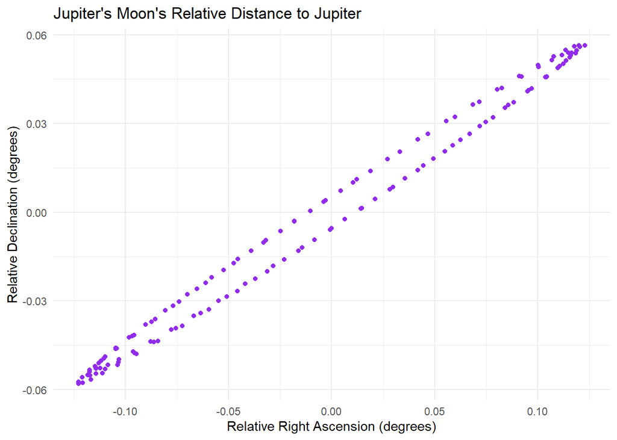

```r
ggplot(relative_position, aes(RA_dif, DEC_dif)) +
  labs(title = "Jupiter's Moon's Relative Distance to Jupiter",
       x = "Relative Right Ascension (degrees)",
       y = "Relative Declination (degrees)") +
  geom_point(color = "purple2") + theme_minimal()
```

## Fitting the Ellipse

Recall that originally, we needed this ellipse for its semi-major axis. This means we must accurately calculate said semi-major axis (in degrees). To do so, we will use a pre-constructed ellipse-fitter.

First we call the external file “fitellipse.r,” which contains the necessary code. Then we will fit the ellipse using the provided “fit_ellipse()” function and print out the results (“res”). This will return a variety of information, but what we are interested is the semi-major axis, which happens to be 0.1312755 degrees. For simplicity’s sake and future use, we created the variable “semi_major” to store this number.

```r
#calling the file
source("fitellipse.r")

#fitting the ellipse
res = fit_ellipse(relative_position$RA_dif, relative_position$DEC_dif)
#printing result
res
```

```
$coef
            a             b             c             d             e
-1.578034e-01  6.724112e-01 -7.231606e-01  3.058420e-05 -6.752237e-05
            f
 2.121367e-05

$center
            x             y
-0.0002696674 -0.0001720570

$semimajor
[1] 0.1312755

$semiminor
[1] 0.004910771

$angle
[1] 0.4358365
```

```r
#assigning semi-major axis value to a variable
semi_major = 0.1312755
```

## Calculate Average Distance to Jupiter

Because we need the average separation between Jupiter and its moon to be in AUs for the mass equation, we need to use the semi-major axis and average distance to Jupiter to obtain this number. The equation for this is as follows, with *distance* in AUs, and *θ* as the semi-major axis in degrees.

$$θ/360 = separation/2π(distance)$$

Which can be simplified to:

$$separation = (π \times distance \times θ)/180$$

We already have the semi-major axis in degrees, so now we will calculate the average distance to Jupiter by taking the mean of the entire column of Jupiter’s “Dist_AU” variable (Distance from Earth in AUs) from its dataset. The result was 5.500493 AUs, which we assigned to the variable “average_dist.”

```r
average_dist <- mean(jupiter$Dist_AU, na.rm = TRUE)
average_dist
```

```
[1] 5.500493
```

## Calculate Separation

Now that we have both the average distance to Jupiter in AUs (“average_dist”) and the semi-major axis in degrees (“semi-major”), we can calculate the average separation in AUs. The result was 0.01260267 AUs, and we assigned it to the variable “sep” for future use.

```r
sep <- (pi*average_dist*semi_major)/180
sep
```

```
[1] 0.01260267
```

## Calculate Orbital Period

We’ve almost got everything we need to calculate the mass of Jupiter! All that remains to be calculated is the orbital period in years. To get a good visualization of this, we will plot RA (in degrees) against Jupiter Day (JD). In order to more easily identify peaks (relative maxima) so we can calculate how much time elapses between them, we will download the package “pracma.” Then we will find the peaks, create the ggplot visualization, and use selection across peak indexes to zero in on one orbital period. We found that one orbital period is 16.66667 days and 0.0456621 years. The variable “per_years” contains the orbital period in years.

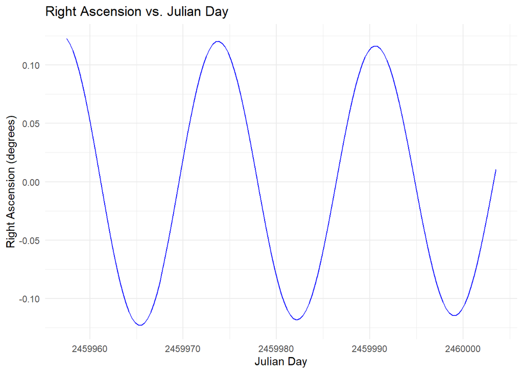

```r
#loading the necessary package for peaks
library(pracma)

#name columns for simplicity
col1 <- jupiter$JD
col2 <- relative_position$RA_dif
#find indices of peaks
peaks <- findpeaks(col2)

#plot RA vs JD
ggplot() +
  geom_line(aes(col1,col2), color = "blue") +
  ggtitle("Right Ascension vs. Julian Day") +
  xlab("Julian Day") +
  ylab("Right Ascension (degrees)") +
  theme_minimal()
```

```r
#calculating the length of one orbit
first_peak <- peaks[1, 2]  #first peak index
second_peak <- peaks[2, 2]  #second peak index

#calculate the period in days
period <- col1[second_peak] - col1[first_peak]
#print out period (days)
period
```

```
[1] 16.66667
```

```r
#convert to years
per_years <- period/365
#print out period (years)
per_years
```

```
[1] 0.0456621
```

# Calculate Jupiter’s Mass

Now we have everything for our mass equation! As a reminder, this is what it looks like:

$$a^3/p^2 = (M_1 + M_2)☉$$

Our estimated mass of Jupiter is 0.0009600109 solar mass. In order to make this a little more readable as far as units go, we can convert it to kg using the mass of the sun, which is 1.988E+30 kg. This came out to be about 1.908502e+27 kg. We assigned 0.0009600109 to the variable “mass_solar” and 1.908502e+27 to the variable “mass_kg.”

```r
mass_solar <- (sep^3)/(per_years^2)
mass_solar
```

```
[1] 0.0009600109
```

```r
mass_kg <- mass_solar*1.988E+30
mass_kg
```

```
[1] 1.908502e+27
```

## Check Percentage Error

The last step of the process is checking our percent error with the true mass of Jupiter, which is 0.00095523138832998 solar mass, or 1.8986E+27 kg. We found our percentage error to be approximately 0.5%.

```r
percentage_error <- ((abs(mass_solar - 0.00095523138832998))/0.00095523138832998)*100

percentage_error
```

```
[1] 0.5003541
```